# ENGR-E599 Machine Learning for Signal Processing

# Assignment 2

### Samvat Rastogi | samrasto@indiana.edu

# Problem 1: De-beeper

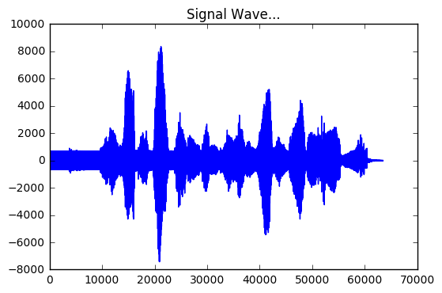

```python
import matplotlib.pyplot as plt
import wave
import numpy as np


x = wave.open('data/x.wav', 'r')
#Extract Raw Audio from Wav File
signal = x.readframes(-1)
signal = np.fromstring(signal, 'Int16')
fs = x.getframerate()
plt.figure(1)
plt.title('Signal Wave...')
plt.plot(signal)
plt.show()
```

```python
#Given
N = 1600

n = (np.arange(N)).reshape(N,1)
f = (np.arange(N)).reshape(1,N)

R = np.cos((2*np.pi*f)*(n/N))
I = np.sin((2*np.pi*f)*(n/N))

F = R - 1j*I
#DFT Matrix
F.shape
```

```
(1600, 1600)
```

```python
hann_window = np.hanning(N).reshape(1,N)
```

```python
n_rows = int(len(signal)/N)*2
X = np.zeros((N, n_rows))
index = 0
for i in range(n_rows):
    m = int(N/(i or 1))
    datum = signal[m:m+N]
    X[:,index] = datum * hann_window
    x = np.zeros(N)
    index+=1
```

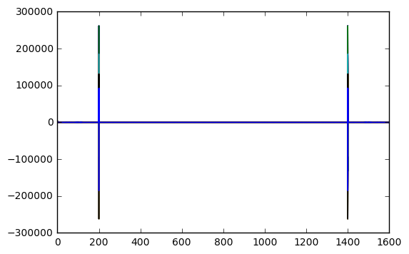

```python
FX = F.dot(X)
plt.plot(FX.real)
plt.show()
```

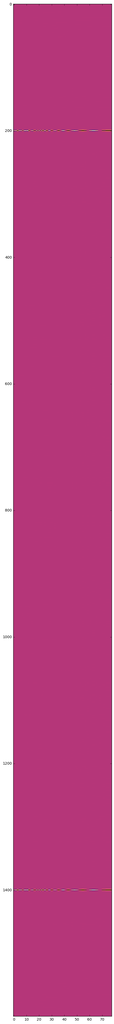

```python
plt.figure(figsize = (20, 50))
plt.imshow(FX.real, cmap="magma", aspect=".5")
plt.show()
```

```python
FX[195:205][:] = 0 + 1j * 0
FX[1395:1405][:] = 0 + 1j * 0
```

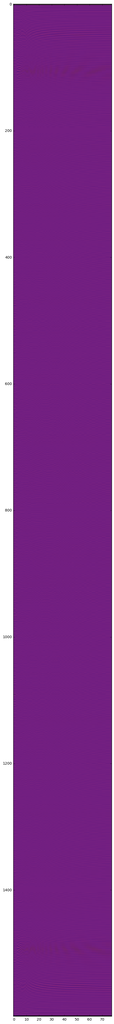

```python
plt.figure(figsize = (20, 50))
plt.imshow(FX.real, cmap="magma", aspect=".5")
plt.show()
```

```python
Fi = R + 1j*I
FiFX = np.dot(Fi, FX)
FiFX_abs = FiFX.real
FiFX_abs.shape
```

```
(1600, 78)
```

```python
recovered_signal = np.zeros(signal.shape[0])
k = 0
m = FiFX_abs.shape[1]
for i in range(m):
    recovered_signal[k:k+N] = recovered_signal[k:k+N] + FiFX_abs[:,i].T
    k = int(k+ N/2)

print(recovered_signal)
```

```
[  75.91828656  148.14686841  132.81791647 ...,    0.            0.            0.        ]
```

```python
import scipy.io.wavfile as write
from scipy.io.wavfile import write
final_signal = (recovered_signal).astype(int)
write('data/x_recovered.wav', fs, final_signal)
```

Recoved Sound Link: x_recovered.wav

## Problem 2: Stereo Matching

```python
import scipy.io
from matplotlib import image as img
import matplotlib.pyplot as plt
import numpy as np
```

[figure not shown]

```python
X_L = img.imread('data/im0.ppm')
plt.imshow(X_L)
plt.show()
```

[figure not shown]

```python
X_R = img.imread('data/im8.ppm')
plt.clf()
plt.imshow(X_R)
plt.show()
```

```python
#Dimension of X_L
L_rows = X_L.shape[0]
L_cols = X_L.shape[1]

#Dimension of X_R
R_rows = X_R.shape[0]
R_cols = X_R.shape[1]

search_size = 40
```

```python
D = np.zeros((R_rows, R_cols-search_size))
```

```python
current = 0
for i in range(D.shape[0]):
    for j in range(D.shape[1]):
        previous =  np.linalg.norm(X_R[i,j]-X_L[i,j])
        for k in range(search_size):
            possible_range = j + k
            current = np.linalg.norm(X_R[i,j]-X_L[i,possible_range])
            if(current < previous):
                previous = current
                D[i,j] = k
```

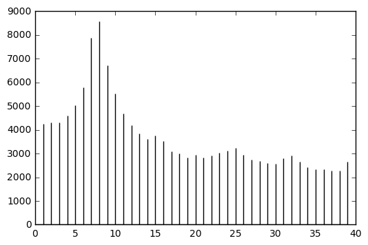

```python
plt.hist(D.ravel(), bins=10000)
plt.show()
```

# Problem 3: GMM and kmeans clustering for stereo matching

```python
D_dash = D.ravel()
D= D.astype(int)
```

```python
#kmeans
def get_new_centroids(data):
    new_centroids = []
    for i in range(len(data)):
        new_centroids.append(np.mean(data[i]))
    return new_centroids
```

```python
#Number of clusters
n_clusters = 2
tempD = np.empty((D.shape[0], D.shape[1]))
np.copyto(tempD,D)
clusters = [[0] * 1 for i in range(n_clusters)]
centroids = [20,38]
#First Iteration
for i in range(D.shape[0]):
    for j in range(D.shape[1]):
        distance = []
        for c in centroids:
            distance.append(np.linalg.norm(D[i][j]-c))
            #print(D[i][j], c, distance)
        near_centroid = distance.index(min(distance))
        clusters[near_centroid].append(D[i][j])
        tempD[i][j] = centroids[near_centroid]


n_iterations = 50
#Next Iterations
for i in range(n_iterations-1):
    temp = [[0] * 1 for i in range(n_clusters)]
    centroids = get_new_centroids(clusters)
    clusters = []
    for i in range(D.shape[0]):
        for j in range(D.shape[1]):
            distance = []
            for c in centroids:
                distance.append(np.linalg.norm(D[i][j]-c))
            near_centroid = distance.index(min(distance))
            temp[near_centroid].append(D[i][j])
            tempD[i][j] = centroids[near_centroid]
    clusters = temp
```

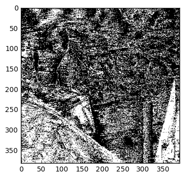

```python
plt.imshow(tempD)
plt.gray()
plt.show()
```

```python
def get_variance(data, mu):
    gmm_variance = []
    for mean in mu:
        variance = 0
        for i in range(data.shape[0]):
            for j in range(data.shape[1]):
                variance += data[i][j]-mean
        variance = variance/(data.size-1)
        gmm_variance.append(variance)
    return gmm_variance

def compute_responsibilites(means, variances, p, data):
    phis = get_gaussian(means, variances, data)
    r = []
    denominator = 0
    for i in range(len(means)):
        denominator = denominator + (p[0,i]*phis[i])
    for i in range(len(means)):
        numerator = p[0,i]*phis[i]
        r.append(numerator/denominator)
    return r

def get_gaussian(means, variances, data):
    phi = []
    for i in range(len(means)):
        phi.append((data-means[i])**2/variances[i])
    return phi

def get_means(r, data, gmm_n_clusters):
    means = []
    for i in range(gmm_n_clusters):
        term1 = 0
        for j in range(r[i].size):
            term1 = term1 + r[i][0][j]
        mean = 0
        for k in range(data.size):
            mean = mean + (term1*data[0][k]/term1)
        means.append(mean)
    return means
```

```python
#GMM
#Number of clusters
import random
gmm_n_clusters = 2
gmm_means = random.sample(range(0,39),gmm_n_clusters)
gmm_variances = get_variance(D, gmm_means)
gmm_p = np.random.dirichlet(np.ones(gmm_n_clusters),size=1)
D_gmm = np.empty((D.shape[0], D.shape[1]))
np.copyto(D_gmm,D)
D_gmm = D_gmm.astype(int)
D_gmm = D_gmm.reshape((1,(D_gmm.size)))
#responsibilities #expectations
r = compute_responsibilites(gmm_means, gmm_variances, gmm_p, D_gmm)
print(r)
```

```
[array([[  1.        ,   1.64443313,   1.14154693, ...,  -2.2745726 ,
         20.35765096,   8.45646943]]), array([[ -0.        ,  -0.64443313,  -0.14154693, ...,   3.2745726 ,
        -19.35765096,  -7.45646943]])]
```

```python
#maximization
gmm_means = get_means(np.array(r), D_gmm, gmm_n_clusters)
#gmm_variances = get_scaled_variances(gmm_means, gmm_n_clusters, D_gmm)
print(gmm_means)
```

```
[2395915.0, 2395915.0]
```

[output not shown]

[output cut: 101 more lines]

[output not shown]

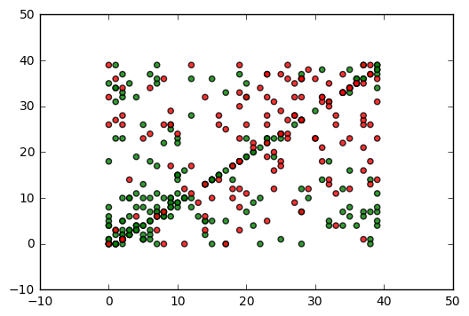

```python
#Result validation only
from sklearn import mixture
tempDgmm = np.reshape(D_gmm,(381,390))
print(tempDgmm.shape)
def fit_samples(tempDgmm):
    result = mixture.GMM(n_components = 2, covariance_type='full')
    result.fit(tempDgmm)
    #result.predict(tempDgmm)
    print(result.means_)
    colors = ['r' if i==0 else 'g' for i in result.predict(tempDgmm)]
    ax = plt.gca()
    ax.scatter(tempDgmm[:,0], tempDgmm[:,1], c=colors, alpha=0.8)
    plt.show()
fit_samples(tempDgmm)
```

## Problem 4: DCT and PCA

[figure not shown]

```python
image_X = img.imread('data/IMG_1878.jpg')
plt.imshow(image_X)
plt.show()
```

```python
X_red = np.array(image_X[:,:,0])
X_green = np.array(image_X[:,:,1])
X_blue = np.array(image_X[:,:,2])
```

```python
from random import randint

#Random 3 row from Red
a = 0
r = []
for i in range(3):
    a = randint(0,1015)
    r.append(X_red[a:a+8,:])

#Random 3 row from Green
a = 0
g = []
for i in range(3):
    a = randint(0,1015)
    g.append(X_green[a:a+8,:])

#Random 3 row from Blue
a = 0
b = []
for i in range(3):
    a = randint(0,1015)
    b.append(X_blue[a:a+8,:])

r = np.array(r)
g = np.array(g)
b = np.array(b)
```

```python
r_temp = r.reshape((8,3*768), order='C')
b_temp = b.reshape((8,3*768), order='C')
g_temp = g.reshape((8,3*768), order='C')

R = np.hstack((r_temp,g_temp, b_temp))
```

```python
rows_mean = np.zeros((8,1))
for i in range(R.shape[0]):
    rows_mean[i] = np.mean(R[i])

R_dash = R - rows_mean

covariance_matrix = np.dot(R_dash, R_dash.T)/8
```

```python
#Power Iteration Routine
def powerIteration(X):
    v_i = np.random.rand(X.shape[1],1)
    for i in range(5000):
        v_i = np.dot(X,v_i)
        v_i /= np.linalg.norm(v_i)
    return v_i
```

```python
evectors = []
evalues = []

for i in range(8):
    evectors.append(powerIteration(covariance_matrix))
    evalues.append(np.dot(covariance_matrix, evectors[i])/evectors[i])
    covariance_matrix = covariance_matrix - evalues[i] * np.dot(evectors[i], evectors[i].T)
```

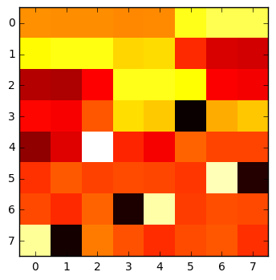

```python
W = np.hstack(evectors)
PCA_result = np.dot(W.T,R)
plt.imshow(W.T, cmap='hot', interpolation='nearest')
plt.show()
```

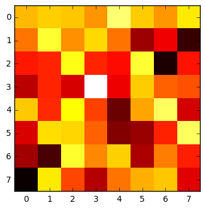

```python
#For 30 block size
#Random 3 row from Red
a = 0
r = []
for i in range(30):
    a = randint(0,1015)
    r.append(X_red[a:a+8,:])

#Random 3 row from Green
a = 0
g = []
for i in range(30):
    a = randint(0,1015)
    g.append(X_green[a:a+8,:])

#Random 3 row from Blue
a = 0
b = []
for i in range(30):
    a = randint(0,1015)
    b.append(X_blue[a:a+8,:])

r = np.array(r)
g = np.array(g)
b = np.array(b)

r_temp = r.reshape((8,30*768), order='C')
b_temp = b.reshape((8,30*768), order='C')
g_temp = g.reshape((8,30*768), order='C')

R = np.hstack((r_temp,g_temp, b_temp))

rows_mean = np.zeros((8,1))
for i in range(R.shape[0]):
    rows_mean[i] = np.mean(R[i])

R_dash = R - rows_mean

covariance_matrix = np.dot(R_dash, R_dash.T)/8

evectors = []
evalues = []

for i in range(8):
    evectors.append(powerIteration(covariance_matrix))
    evalues.append(np.dot(covariance_matrix, evectors[i])/evectors[i])
    covariance_matrix = covariance_matrix - evalues[i] * np.dot(evectors[i], evectors[i].T)

W = np.hstack(evectors)
PCA_result = np.dot(W.T,R)
plt.imshow(W.T, cmap='hot', interpolation='nearest')
plt.show()
```

##### Pros and Cons of PCA and DCT

In DCT, the transformation is orthogonal in nature. It means the inverse of it is its transpose and energy is preserved. This helps to use faster algorithms for computation[1]. Also, DCT is data independent which makes it a better encoder and decoder than PCA. For a large dataset, there is a high chance that higher ranked eigen vector may look very similiar to a sine or cosine wave, hence this makes DCT an approximation of eigenbasis[2]. One major drawback of DCT is that the input from pre-processed blocks are integered values and output are real valued. Thus we need to perform quantization to produce integer valued output[1].

Key Advantages of PCA are low noise sensitivity, the decreased requirements for capacity and memory and increased efficiency in smaller dimensions. PCA can do the analysis for entire dataset without considering the fundamental class structure and does not require large computations.[3] Adaptivity to data can be a disadvantage. To reconstruct the data, the PCA needs the coefficients and the transform matrix.[2]

# References

- [1]: Image Compression: How Math led to the JPEG2000 Standard, whydomath.org, http://www.whydomath.org/node/wavlets/dct.html
- [2]: Relationship between DCT and PCA, pichenettes, dsp.stockexchange.org, https://dsp.stackexchange.com/a/7862
- [3]: An Overview of Principal Component Analysis, 2013, Sasan Karamizadeh, Shahidan M. Abdullah, Azizah A. Manaf, Mazdak Zamani, Alireza Hooman, https://file.scirp.org/pdf/JSIP_2013101711003963.pdf